# R Notebook

# 9.16.2 histograms

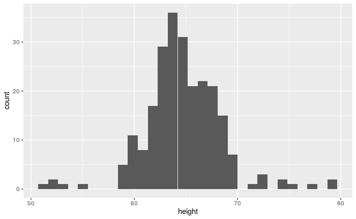

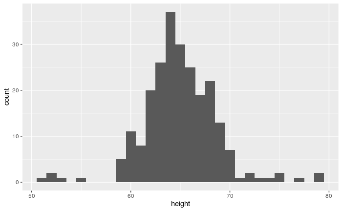

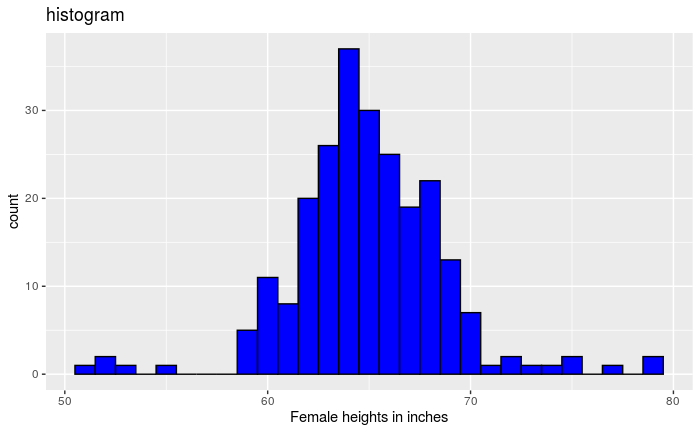

# 9.16.3 density plots

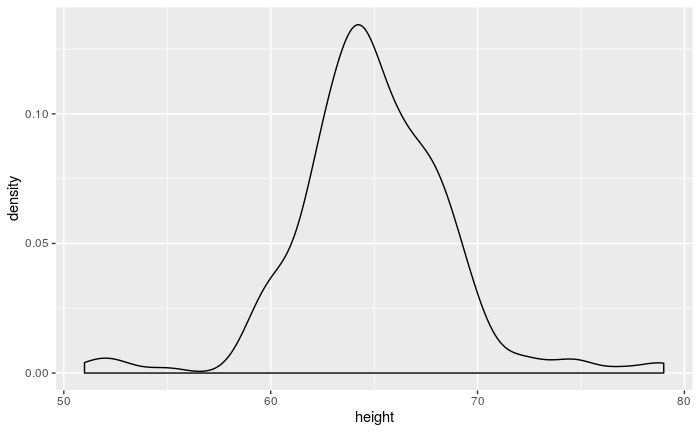

```r
heights%>%
  filter(sex=='Female')%>%
  ggplot(aes(height))+
  geom_density()
```

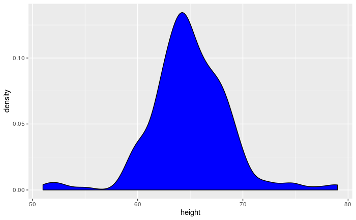

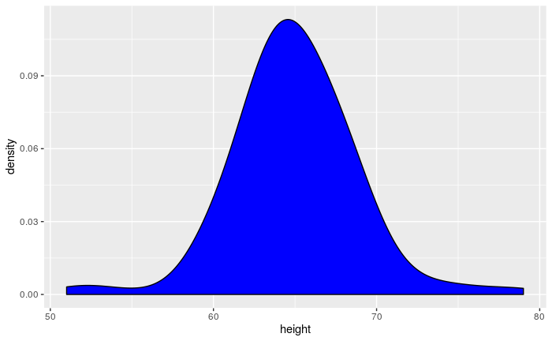

```r
heights%>%
  filter(sex=='Female')%>%
  ggplot(aes(height))+
  geom_density(fill='blue',adjust=2)
```

# 9.16.4 boxplots

# 9.16.5 qq-plots

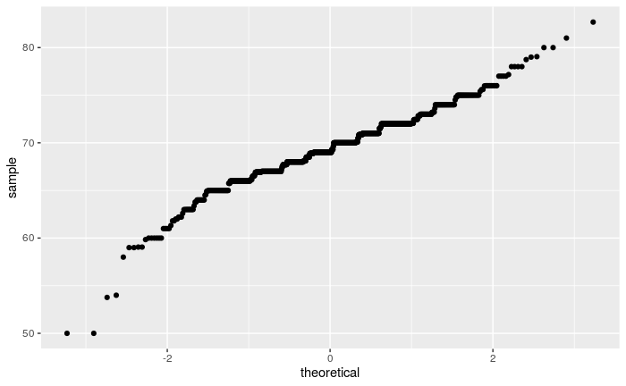

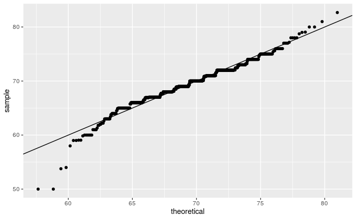

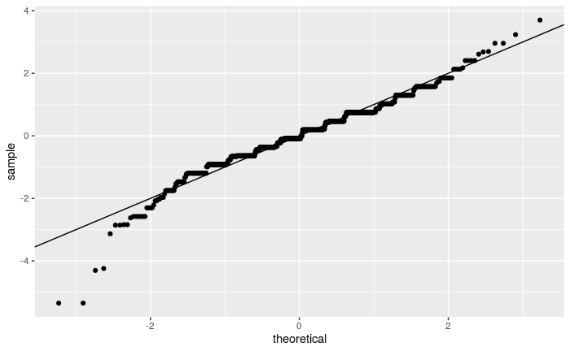

# 9.16.6 images

```r
x<-expand.grid(x=1:12,y=1:10)%>%
  mutate(z=1:120)
x
```

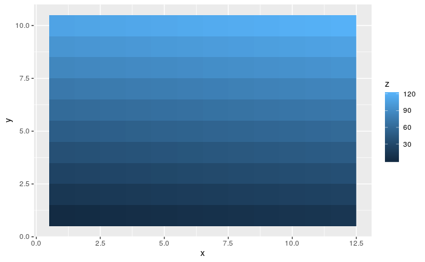

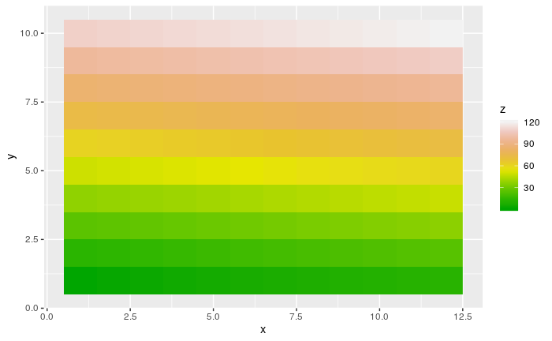

# 9.16.7 quick plots

```r
x<-heights%>%
  filter(sex=='Male')%>%
  pull(height)
```

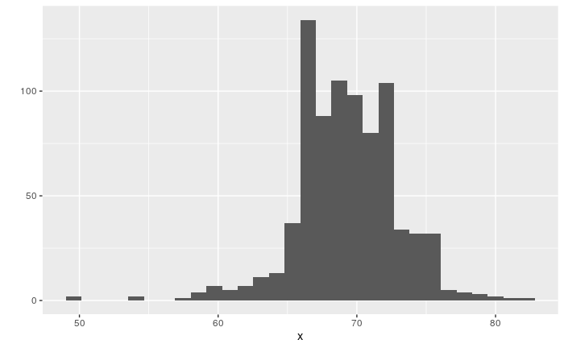

```r
qplot(x)
```

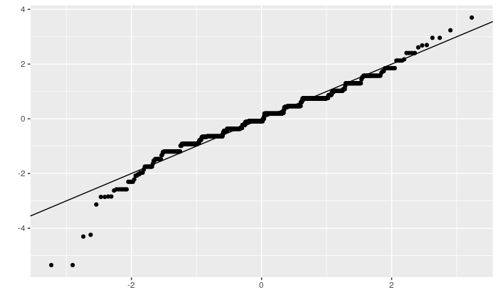

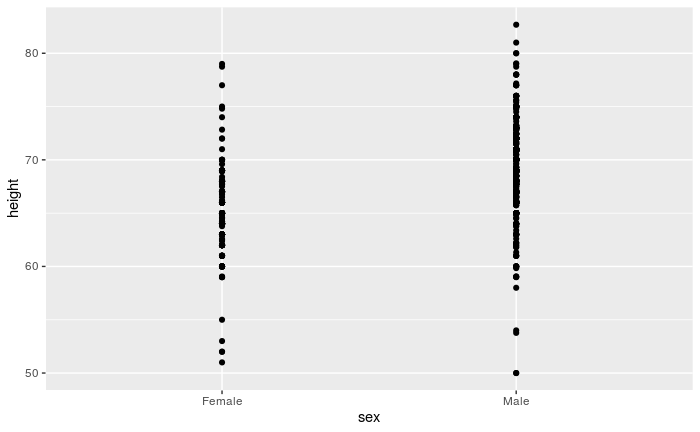

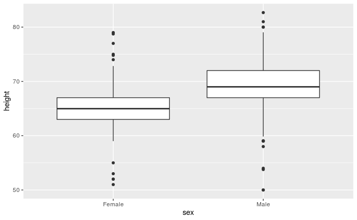

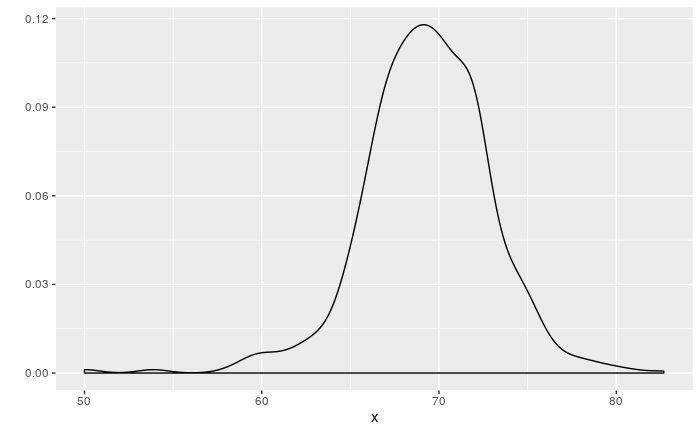

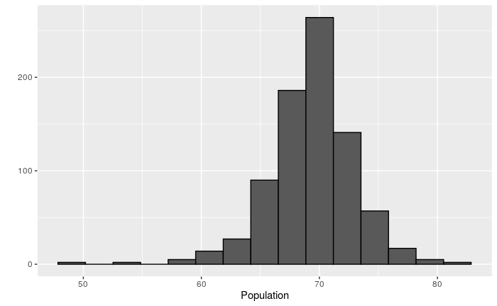

```r
qplot(x,bins=15,color=I('black'),xlab='Population')
```

In general, the function I is used in R to say “keep it as it is”.

# 9.17 exercises

1.Now we are going to use the geom_histogram function to make a histogram of the heights in the height data frame. When reading the documentation for this function we see that it requires just one mapping, the values to be used for the histogram. Make a histogram of all the plots.

What is the variable containing the heights?

A. sex

B. heights

C. height

2.Now create a ggplot object using the pipe to assign the heights data to a ggplot object. Assign height to the x values through the aes function.

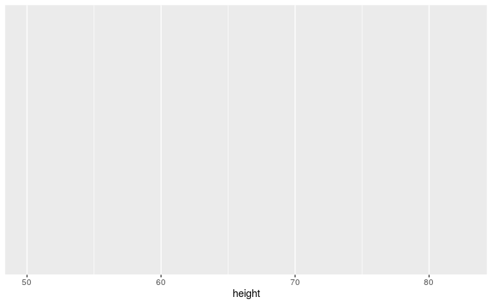

3.Now we are ready to add a layer to actually make the histogram. Use the object created in the previous exercise and the geom_histogram function to make the histogram.

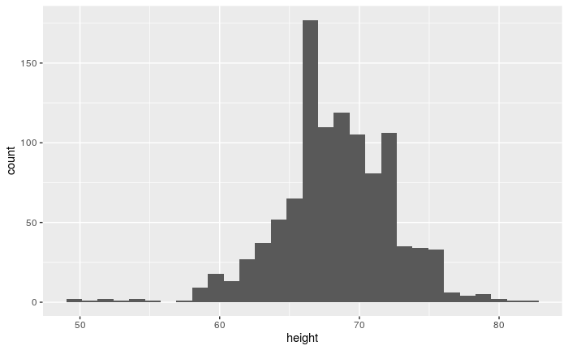

4.Note that when we run the code in the previous exercise we get the warning: stat_bin() using bins = 30. Pick better value with binwidth.`

Use the binwidth argument to change the histogram made in the previous exercise to use bins of size 1 inch.

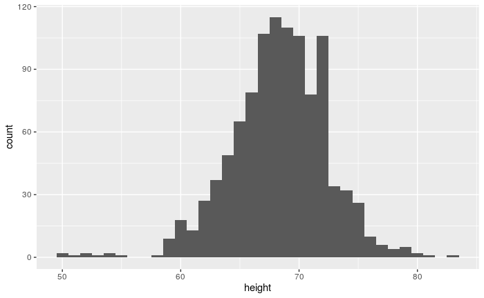

5.Instead of a histogram, we are going to make a smooth density plot. In this case we will not make an object, but instead render the plot with one line of code. Change the geometry in the code previously used to make a smooth density instead of a histogram.

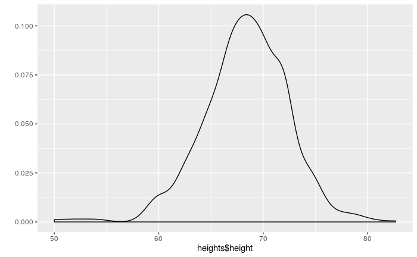

6.Now we are going to make a density plot for males and females separately. We can do this using the group argument. We assign groups via the aesthetic mapping as each point needs to a group before making the calculations needed to estimate a density.

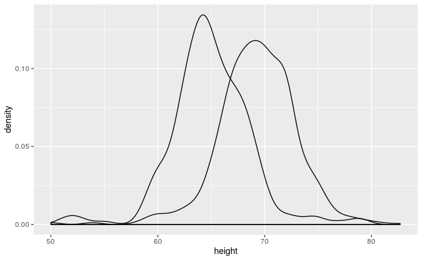

7.We can also assign groups through the color argument. This has the added benefit that it uses color to distinguish the groups. Change the code above to use color

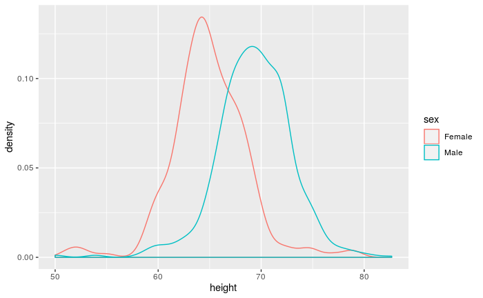

8.We can also assign groups through the fill argument. This has the added benefit that it uses colors to distinguish the groups, like this:

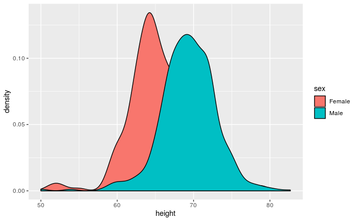

However, here the second density is drawn over the other. We can make the curves more visible by using alpha blending to add transparency. Set the alpha parameter to 0.2 in the geom_density function to make this change.

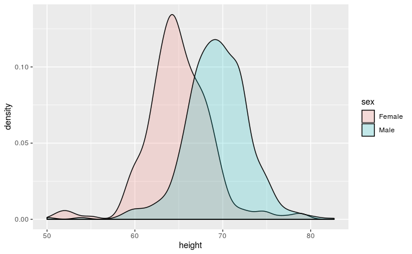

…